# Risk Factor Analysis

## Outcome Variable

**Outcome Variable:** ever_stunted

## Predictor Variables

**Intervention Variable:** feducyrs

**Adjustment Set:**

- arm
- W_mage
- meducyrs
- hhwealth_quart
- W_mhtcm
- W_mwtkg
- W_mbmi
- W_gagebrth
- W_birthwt
- W_birthlen
- single
- delta_W_mage
- delta_meducyrs
- delta_hhwealth_quart
- delta_W_mhtcm
- delta_W_mwtkg
- delta_W_mbmi
- delta_W_gagebrth
- delta_W_birthwt
- delta_W_birthlen
- delta_single

## Stratifying Variables

The analysis was stratified on these variable(s):

- agecat
- studyid
- country

## Data Summary

| agecat | studyid | country | feducyrs | ever_stunted | n_cell | n |
| --- | --- | --- | --- | --- | --- | --- |
| 0-24 months | ki0047075b-MAL-ED | BANGLADESH | High | 0 | 31 | 149 |
| 0-24 months | ki0047075b-MAL-ED | BANGLADESH | High | 1 | 23 | 149 |
| 0-24 months | ki0047075b-MAL-ED | BANGLADESH | Low | 0 | 15 | 149 |
| 0-24 months | ki0047075b-MAL-ED | BANGLADESH | Low | 1 | 25 | 149 |
| 0-24 months | ki0047075b-MAL-ED | BANGLADESH | Medium | 0 | 19 | 149 |
| 0-24 months | ki0047075b-MAL-ED | BANGLADESH | Medium | 1 | 36 | 149 |
| 0-24 months | ki0047075b-MAL-ED | INDIA | High | 0 | 17 | 147 |
| 0-24 months | ki0047075b-MAL-ED | INDIA | High | 1 | 27 | 147 |
| 0-24 months | ki0047075b-MAL-ED | INDIA | Low | 0 | 28 | 147 |
| 0-24 months | ki0047075b-MAL-ED | INDIA | Low | 1 | 31 | 147 |
| 0-24 months | ki0047075b-MAL-ED | INDIA | Medium | 0 | 18 | 147 |
| 0-24 months | ki0047075b-MAL-ED | INDIA | Medium | 1 | 26 | 147 |
| 0-24 months | ki0047075b-MAL-ED | NEPAL | High | 0 | 32 | 98 |
| 0-24 months | ki0047075b-MAL-ED | NEPAL | High | 1 | 10 | 98 |
| 0-24 months | ki0047075b-MAL-ED | NEPAL | Low | 0 | 16 | 98 |
| 0-24 months | ki0047075b-MAL-ED | NEPAL | Low | 1 | 12 | 98 |
| 0-24 months | ki0047075b-MAL-ED | NEPAL | Medium | 0 | 15 | 98 |
| 0-24 months | ki0047075b-MAL-ED | NEPAL | Medium | 1 | 13 | 98 |
| 0-24 months | ki0047075b-MAL-ED | PERU | High | 0 | 45 | 250 |
| 0-24 months | ki0047075b-MAL-ED | PERU | High | 1 | 75 | 250 |
| 0-24 months | ki0047075b-MAL-ED | PERU | Low | 0 | 28 | 250 |
| 0-24 months | ki0047075b-MAL-ED | PERU | Low | 1 | 41 | 250 |
| 0-24 months | ki0047075b-MAL-ED | PERU | Medium | 0 | 20 | 250 |
| 0-24 months | ki0047075b-MAL-ED | PERU | Medium | 1 | 41 | 250 |
| 0-24 months | ki0047075b-MAL-ED | SOUTH AFRICA | High | 0 | 14 | 110 |
| 0-24 months | ki0047075b-MAL-ED | SOUTH AFRICA | High | 1 | 29 | 110 |
| 0-24 months | ki0047075b-MAL-ED | SOUTH AFRICA | Low | 0 | 18 | 110 |
| 0-24 months | ki0047075b-MAL-ED | SOUTH AFRICA | Low | 1 | 19 | 110 |
| 0-24 months | ki0047075b-MAL-ED | SOUTH AFRICA | Medium | 0 | 10 | 110 |
| 0-24 months | ki0047075b-MAL-ED | SOUTH AFRICA | Medium | 1 | 20 | 110 |

[output cut: 330 more lines]

The following strata were considered:

- agecat: 0-24 months, studyid: ki0047075b-MAL-ED, country: BANGLADESH
- agecat: 0-24 months, studyid: ki0047075b-MAL-ED, country: INDIA
- agecat: 0-24 months, studyid: ki0047075b-MAL-ED, country: NEPAL
- agecat: 0-24 months, studyid: ki0047075b-MAL-ED, country: PERU
- agecat: 0-24 months, studyid: ki0047075b-MAL-ED, country: SOUTH AFRICA
- agecat: 0-24 months, studyid: ki0047075b-MAL-ED, country: TANZANIA, UNITED REPUBLIC OF
- agecat: 0-24 months, studyid: ki1000304b-SAS-CompFeed, country: INDIA
- agecat: 0-24 months, studyid: ki1000304b-SAS-FoodSuppl, country: INDIA
- agecat: 0-24 months, studyid: ki1017093b-PROVIDE, country: BANGLADESH
- agecat: 0-24 months, studyid: ki1017093c-NIH-Crypto, country: BANGLADESH
- agecat: 0-24 months, studyid: ki1066203-TanzaniaChild2, country: TANZANIA, UNITED REPUBLIC OF
- agecat: 0-24 months, studyid: ki1113344-GMS-Nepal, country: NEPAL
- agecat: 0-24 months, studyid: ki1119695-PROBIT, country: BELARUS
- agecat: 0-24 months, studyid: ki1126311-ZVITAMBO, country: ZIMBABWE
- agecat: 0-24 months, studyid: ki1135781-COHORTS, country: GUATEMALA
- agecat: 0-24 months, studyid: ki1135781-COHORTS, country: INDIA
- agecat: 0-24 months, studyid: ki1135781-COHORTS, country: PHILIPPINES
- agecat: 0-24 months, studyid: ki1148112-LCNI-5, country: MALAWI
- agecat: 0-24 months, studyid: kiGH5241-JiVitA-3, country: BANGLADESH
- agecat: 0-24 months, studyid: kiGH5241-JiVitA-4, country: BANGLADESH
- agecat: 0-6 months, studyid: ki0047075b-MAL-ED, country: BANGLADESH
- agecat: 0-6 months, studyid: ki0047075b-MAL-ED, country: INDIA
- agecat: 0-6 months, studyid: ki0047075b-MAL-ED, country: NEPAL
- agecat: 0-6 months, studyid: ki0047075b-MAL-ED, country: PERU
- agecat: 0-6 months, studyid: ki0047075b-MAL-ED, country: SOUTH AFRICA
- agecat: 0-6 months, studyid: ki0047075b-MAL-ED, country: TANZANIA, UNITED REPUBLIC OF
- agecat: 0-6 months, studyid: ki1000304b-SAS-CompFeed, country: INDIA
- agecat: 0-6 months, studyid: ki1000304b-SAS-FoodSuppl, country: INDIA
- agecat: 0-6 months, studyid: ki1017093b-PROVIDE, country: BANGLADESH
- agecat: 0-6 months, studyid: ki1017093c-NIH-Crypto, country: BANGLADESH
- agecat: 0-6 months, studyid: ki1066203-TanzaniaChild2, country: TANZANIA, UNITED REPUBLIC OF
- agecat: 0-6 months, studyid: ki1113344-GMS-Nepal, country: NEPAL
- agecat: 0-6 months, studyid: ki1119695-PROBIT, country: BELARUS
- agecat: 0-6 months, studyid: ki1126311-ZVITAMBO, country: ZIMBABWE
- agecat: 0-6 months, studyid: ki1135781-COHORTS, country: GUATEMALA
- agecat: 0-6 months, studyid: ki1135781-COHORTS, country: INDIA
- agecat: 0-6 months, studyid: ki1135781-COHORTS, country: PHILIPPINES
- agecat: 0-6 months, studyid: ki1148112-LCNI-5, country: MALAWI
- agecat: 0-6 months, studyid: kiGH5241-JiVitA-3, country: BANGLADESH
- agecat: 0-6 months, studyid: kiGH5241-JiVitA-4, country: BANGLADESH
- agecat: 6-24 months, studyid: ki0047075b-MAL-ED, country: BANGLADESH
- agecat: 6-24 months, studyid: ki0047075b-MAL-ED, country: INDIA
- agecat: 6-24 months, studyid: ki0047075b-MAL-ED, country: NEPAL
- agecat: 6-24 months, studyid: ki0047075b-MAL-ED, country: PERU
- agecat: 6-24 months, studyid: ki0047075b-MAL-ED, country: SOUTH AFRICA
- agecat: 6-24 months, studyid: ki0047075b-MAL-ED, country: TANZANIA, UNITED REPUBLIC OF
- agecat: 6-24 months, studyid: ki1000304b-SAS-CompFeed, country: INDIA
- agecat: 6-24 months, studyid: ki1000304b-SAS-FoodSuppl, country: INDIA
- agecat: 6-24 months, studyid: ki1017093b-PROVIDE, country: BANGLADESH
- agecat: 6-24 months, studyid: ki1017093c-NIH-Crypto, country: BANGLADESH
- agecat: 6-24 months, studyid: ki1066203-TanzaniaChild2, country: TANZANIA, UNITED REPUBLIC OF
- agecat: 6-24 months, studyid: ki1113344-GMS-Nepal, country: NEPAL
- agecat: 6-24 months, studyid: ki1119695-PROBIT, country: BELARUS
- agecat: 6-24 months, studyid: ki1126311-ZVITAMBO, country: ZIMBABWE
- agecat: 6-24 months, studyid: ki1135781-COHORTS, country: GUATEMALA
- agecat: 6-24 months, studyid: ki1135781-COHORTS, country: INDIA
- agecat: 6-24 months, studyid: ki1135781-COHORTS, country: PHILIPPINES
- agecat: 6-24 months, studyid: ki1148112-LCNI-5, country: MALAWI
- agecat: 6-24 months, studyid: kiGH5241-JiVitA-3, country: BANGLADESH
- agecat: 6-24 months, studyid: kiGH5241-JiVitA-4, country: BANGLADESH

### Dropped Strata

Some strata were dropped due to rare outcomes:

- agecat: 0-24 months, studyid: ki0047075b-MAL-ED, country: TANZANIA, UNITED REPUBLIC OF
- agecat: 0-6 months, studyid: ki0047075b-MAL-ED, country: NEPAL
- agecat: 6-24 months, studyid: ki0047075b-MAL-ED, country: NEPAL
- agecat: 6-24 months, studyid: ki0047075b-MAL-ED, country: TANZANIA, UNITED REPUBLIC OF

## Methods Detail

We’re interested in the causal parameters $E[Y_a]$ for all values of $a \in \mathcal{A}$. These parameters represent the mean outcome if, possibly contrary to fact, we intervened to set all units to have $A=a$. Under the randomization and positivity assumptions, these are identified by the statistical parameters $\psi_a=E_W[E_{Y|A,W}(Y|A=a,W)]$. In addition, we’re interested in the mean of $Y$, $E[Y]$ under no intervention (the observed mean). We will estimate these parameters by using SuperLearner to fit the relevant likelihood factors – $E_{Y|A,W}(Y|A=a,W)$ and $p(A=a|W)$, and then updating our likelihood fit using a joint TMLE.

For unadjusted analyses ($W=\{\}$), initial likelihoods were estimated using Lrnr_glm to estimate the simple $E(Y|A)$ and Lrnr_mean to estimate $p(A)$. For adjusted analyses, a small library containing Lrnr_glmnet, Lrnr_xgboost, and Lrnr_mean was used.

Having estimated these parameters, we will then use the delta method to estimate relative risks and attributable risks relative to a prespecified baseline level of $A$.

# Results Detail

## Results Plots

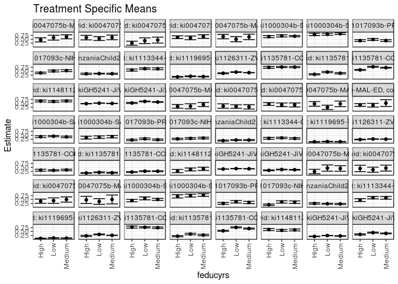

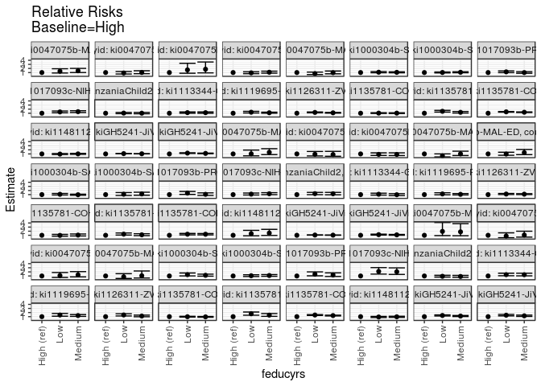

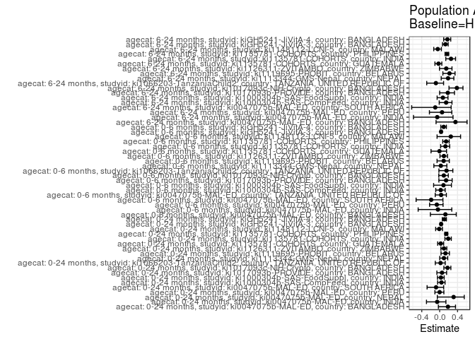

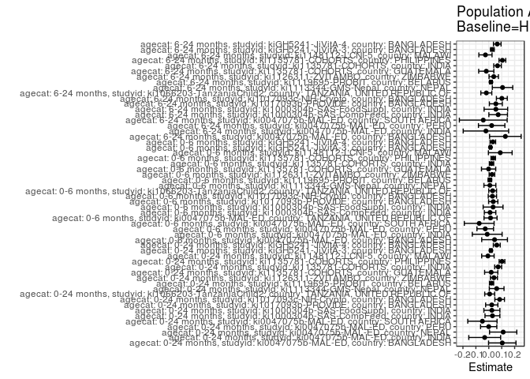

## Results Table

### Parameter: TSM

| agecat | studyid | country | intervention_level | baseline_level | estimate | ci_lower | ci_upper |
| --- | --- | --- | --- | --- | --- | --- | --- |
| 0-24 months | ki0047075b-MAL-ED | BANGLADESH | High | NA | 0.4594091 | 0.3273433 | 0.5914749 |
| 0-24 months | ki0047075b-MAL-ED | BANGLADESH | Low | NA | 0.6007250 | 0.4440303 | 0.7574197 |
| 0-24 months | ki0047075b-MAL-ED | BANGLADESH | Medium | NA | 0.6548401 | 0.5264028 | 0.7832775 |
| 0-24 months | ki0047075b-MAL-ED | INDIA | High | NA | 0.6031007 | 0.4559567 | 0.7502447 |
| 0-24 months | ki0047075b-MAL-ED | INDIA | Low | NA | 0.5412877 | 0.4155620 | 0.6670135 |
| 0-24 months | ki0047075b-MAL-ED | INDIA | Medium | NA | 0.6148023 | 0.4661765 | 0.7634281 |
| 0-24 months | ki0047075b-MAL-ED | NEPAL | High | NA | 0.2458153 | 0.1167218 | 0.3749088 |
| 0-24 months | ki0047075b-MAL-ED | NEPAL | Low | NA | 0.4050821 | 0.2203436 | 0.5898205 |
| 0-24 months | ki0047075b-MAL-ED | NEPAL | Medium | NA | 0.4452888 | 0.2542709 | 0.6363068 |
| 0-24 months | ki0047075b-MAL-ED | PERU | High | NA | 0.6286977 | 0.5412766 | 0.7161189 |
| 0-24 months | ki0047075b-MAL-ED | PERU | Low | NA | 0.5848901 | 0.4665664 | 0.7032137 |
| 0-24 months | ki0047075b-MAL-ED | PERU | Medium | NA | 0.6726009 | 0.5564390 | 0.7887627 |
| 0-24 months | ki0047075b-MAL-ED | SOUTH AFRICA | High | NA | 0.6675965 | 0.5265612 | 0.8086318 |
| 0-24 months | ki0047075b-MAL-ED | SOUTH AFRICA | Low | NA | 0.5029502 | 0.3387811 | 0.6671192 |
| 0-24 months | ki0047075b-MAL-ED | SOUTH AFRICA | Medium | NA | 0.6487187 | 0.4727931 | 0.8246442 |
| 0-24 months | ki1000304b-SAS-CompFeed | INDIA | High | NA | 0.6626050 | 0.5972382 | 0.7279717 |
| 0-24 months | ki1000304b-SAS-CompFeed | INDIA | Low | NA | 0.7131539 | 0.6447194 | 0.7815885 |
| 0-24 months | ki1000304b-SAS-CompFeed | INDIA | Medium | NA | 0.6929837 | 0.6503275 | 0.7356400 |
| 0-24 months | ki1000304b-SAS-FoodSuppl | INDIA | High | NA | 0.8038357 | 0.7300253 | 0.8776460 |
| 0-24 months | ki1000304b-SAS-FoodSuppl | INDIA | Low | NA | 0.8160656 | 0.7539275 | 0.8782037 |
| 0-24 months | ki1000304b-SAS-FoodSuppl | INDIA | Medium | NA | 0.8552277 | 0.8001720 | 0.9102834 |
| 0-24 months | ki1017093b-PROVIDE | BANGLADESH | High | NA | 0.4126816 | 0.3538863 | 0.4714768 |
| 0-24 months | ki1017093b-PROVIDE | BANGLADESH | Low | NA | 0.4827521 | 0.4227452 | 0.5427590 |
| 0-24 months | ki1017093b-PROVIDE | BANGLADESH | Medium | NA | 0.4105726 | 0.3502215 | 0.4709237 |
| 0-24 months | ki1017093c-NIH-Crypto | BANGLADESH | High | NA | 0.3936115 | 0.3443704 | 0.4428525 |
| 0-24 months | ki1017093c-NIH-Crypto | BANGLADESH | Low | NA | 0.5179178 | 0.4572894 | 0.5785462 |
| 0-24 months | ki1017093c-NIH-Crypto | BANGLADESH | Medium | NA | 0.5424930 | 0.4816124 | 0.6033737 |
| 0-24 months | ki1066203-TanzaniaChild2 | TANZANIA, UNITED REPUBLIC OF | High | NA | 0.3397230 | 0.2968924 | 0.3825535 |
| 0-24 months | ki1066203-TanzaniaChild2 | TANZANIA, UNITED REPUBLIC OF | Low | NA | 0.3515021 | 0.3256939 | 0.3773104 |
| 0-24 months | ki1066203-TanzaniaChild2 | TANZANIA, UNITED REPUBLIC OF | Medium | NA | 0.3435393 | 0.3082495 | 0.3788292 |

[output cut: 138 more lines]

### Parameter: E(Y)

| agecat | studyid | country | intervention_level | baseline_level | estimate | ci_lower | ci_upper |
| --- | --- | --- | --- | --- | --- | --- | --- |
| 0-24 months | ki0047075b-MAL-ED | BANGLADESH | NA | NA | 0.5637584 | 0.4838620 | 0.6436548 |
| 0-24 months | ki0047075b-MAL-ED | INDIA | NA | NA | 0.5714286 | 0.4911565 | 0.6517006 |
| 0-24 months | ki0047075b-MAL-ED | NEPAL | NA | NA | 0.3571429 | 0.2617885 | 0.4524972 |
| 0-24 months | ki0047075b-MAL-ED | PERU | NA | NA | 0.6280000 | 0.5679657 | 0.6880343 |
| 0-24 months | ki0047075b-MAL-ED | SOUTH AFRICA | NA | NA | 0.6181818 | 0.5269763 | 0.7093874 |
| 0-24 months | ki1000304b-SAS-CompFeed | INDIA | NA | NA | 0.6908497 | 0.6505448 | 0.7311545 |
| 0-24 months | ki1000304b-SAS-FoodSuppl | INDIA | NA | NA | 0.8277512 | 0.7915095 | 0.8639929 |
| 0-24 months | ki1017093b-PROVIDE | BANGLADESH | NA | NA | 0.4357143 | 0.3989556 | 0.4724730 |
| 0-24 months | ki1017093c-NIH-Crypto | BANGLADESH | NA | NA | 0.4775726 | 0.4419904 | 0.5131548 |
| 0-24 months | ki1066203-TanzaniaChild2 | TANZANIA, UNITED REPUBLIC OF | NA | NA | 0.3466219 | 0.3275107 | 0.3657331 |
| 0-24 months | ki1113344-GMS-Nepal | NEPAL | NA | NA | 0.6408046 | 0.6051362 | 0.6764730 |
| 0-24 months | ki1119695-PROBIT | BELARUS | NA | NA | 0.1652568 | 0.1463320 | 0.1841817 |
| 0-24 months | ki1126311-ZVITAMBO | ZIMBABWE | NA | NA | 0.4136118 | 0.4053631 | 0.4218605 |
| 0-24 months | ki1135781-COHORTS | GUATEMALA | NA | NA | 0.7672000 | 0.7437624 | 0.7906376 |
| 0-24 months | ki1135781-COHORTS | INDIA | NA | NA | 0.3780235 | 0.3530310 | 0.4030160 |
| 0-24 months | ki1135781-COHORTS | PHILIPPINES | NA | NA | 0.6899306 | 0.6730355 | 0.7068256 |
| 0-24 months | ki1148112-LCNI-5 | MALAWI | NA | NA | 0.6371464 | 0.6040748 | 0.6702180 |
| 0-24 months | kiGH5241-JiVitA-3 | BANGLADESH | NA | NA | 0.4931575 | 0.4852626 | 0.5010523 |
| 0-24 months | kiGH5241-JiVitA-4 | BANGLADESH | NA | NA | 0.5820697 | 0.5655159 | 0.5986236 |
| 0-6 months | ki0047075b-MAL-ED | BANGLADESH | NA | NA | 0.3489933 | 0.2722008 | 0.4257857 |
| 0-6 months | ki0047075b-MAL-ED | INDIA | NA | NA | 0.3129252 | 0.2377120 | 0.3881383 |
| 0-6 months | ki0047075b-MAL-ED | PERU | NA | NA | 0.4280000 | 0.3665434 | 0.4894566 |
| 0-6 months | ki0047075b-MAL-ED | SOUTH AFRICA | NA | NA | 0.3909091 | 0.2993052 | 0.4825130 |
| 0-6 months | ki0047075b-MAL-ED | TANZANIA, UNITED REPUBLIC OF | NA | NA | 0.4056604 | 0.3394074 | 0.4719134 |
| 0-6 months | ki1000304b-SAS-CompFeed | INDIA | NA | NA | 0.4250164 | 0.3969651 | 0.4530677 |
| 0-6 months | ki1000304b-SAS-FoodSuppl | INDIA | NA | NA | 0.3894231 | 0.3425088 | 0.4363374 |
| 0-6 months | ki1017093b-PROVIDE | BANGLADESH | NA | NA | 0.2400000 | 0.2083392 | 0.2716608 |
| 0-6 months | ki1017093c-NIH-Crypto | BANGLADESH | NA | NA | 0.3021108 | 0.2694011 | 0.3348205 |
| 0-6 months | ki1066203-TanzaniaChild2 | TANZANIA, UNITED REPUBLIC OF | NA | NA | 0.1951322 | 0.1792173 | 0.2110471 |
| 0-6 months | ki1113344-GMS-Nepal | NEPAL | NA | NA | 0.3189655 | 0.2843148 | 0.3536162 |
| 0-6 months | ki1119695-PROBIT | BELARUS | NA | NA | 0.0977315 | 0.0847284 | 0.1107345 |
| 0-6 months | ki1126311-ZVITAMBO | ZIMBABWE | NA | NA | 0.2565977 | 0.2492783 | 0.2639171 |
| 0-6 months | ki1135781-COHORTS | GUATEMALA | NA | NA | 0.3196078 | 0.2909760 | 0.3482397 |
| 0-6 months | ki1135781-COHORTS | INDIA | NA | NA | 0.1639690 | 0.1447117 | 0.1832264 |
| 0-6 months | ki1135781-COHORTS | PHILIPPINES | NA | NA | 0.2381944 | 0.2226342 | 0.2537546 |
| 0-6 months | ki1148112-LCNI-5 | MALAWI | NA | NA | 0.3558052 | 0.2982716 | 0.4133389 |
| 0-6 months | kiGH5241-JiVitA-3 | BANGLADESH | NA | NA | 0.4111421 | 0.4035964 | 0.4186878 |
| 0-6 months | kiGH5241-JiVitA-4 | BANGLADESH | NA | NA | 0.3469880 | 0.3313196 | 0.3626563 |
| 6-24 months | ki0047075b-MAL-ED | BANGLADESH | NA | NA | 0.3636364 | 0.2625541 | 0.4647186 |
| 6-24 months | ki0047075b-MAL-ED | INDIA | NA | NA | 0.4086022 | 0.3081534 | 0.5090509 |
| 6-24 months | ki0047075b-MAL-ED | PERU | NA | NA | 0.4132231 | 0.3251210 | 0.5013252 |
| 6-24 months | ki0047075b-MAL-ED | SOUTH AFRICA | NA | NA | 0.4310345 | 0.3024734 | 0.5595956 |
| 6-24 months | ki1000304b-SAS-CompFeed | INDIA | NA | NA | 0.5024631 | 0.4586872 | 0.5462389 |
| 6-24 months | ki1000304b-SAS-FoodSuppl | INDIA | NA | NA | 0.7572016 | 0.7031798 | 0.8112234 |
| 6-24 months | ki1017093b-PROVIDE | BANGLADESH | NA | NA | 0.3004386 | 0.2583143 | 0.3425629 |
| 6-24 months | ki1017093c-NIH-Crypto | BANGLADESH | NA | NA | 0.2628458 | 0.2244546 | 0.3012371 |
| 6-24 months | ki1066203-TanzaniaChild2 | TANZANIA, UNITED REPUBLIC OF | NA | NA | 0.2263323 | 0.2057897 | 0.2468748 |
| 6-24 months | ki1113344-GMS-Nepal | NEPAL | NA | NA | 0.5656566 | 0.5167753 | 0.6145378 |
| 6-24 months | ki1119695-PROBIT | BELARUS | NA | NA | 0.0761786 | 0.0621943 | 0.0901630 |
| 6-24 months | ki1126311-ZVITAMBO | ZIMBABWE | NA | NA | 0.2601449 | 0.2506947 | 0.2695951 |
| 6-24 months | ki1135781-COHORTS | GUATEMALA | NA | NA | 0.7617329 | 0.7327499 | 0.7907158 |
| 6-24 months | ki1135781-COHORTS | INDIA | NA | NA | 0.2663274 | 0.2410848 | 0.2915700 |
| 6-24 months | ki1135781-COHORTS | PHILIPPINES | NA | NA | 0.6482312 | 0.6273346 | 0.6691278 |
| 6-24 months | ki1148112-LCNI-5 | MALAWI | NA | NA | 0.5983027 | 0.5621404 | 0.6344650 |
| 6-24 months | kiGH5241-JiVitA-3 | BANGLADESH | NA | NA | 0.2152036 | 0.2057612 | 0.2246461 |
| 6-24 months | kiGH5241-JiVitA-4 | BANGLADESH | NA | NA | 0.3789503 | 0.3597979 | 0.3981028 |

### Parameter: RR

| agecat | studyid | country | intervention_level | baseline_level | estimate | ci_lower | ci_upper |
| --- | --- | --- | --- | --- | --- | --- | --- |
| 0-24 months | ki0047075b-MAL-ED | BANGLADESH | High | High | 1.0000000 | 1.0000000 | 1.000000 |
| 0-24 months | ki0047075b-MAL-ED | BANGLADESH | Low | High | 1.3076036 | 0.8893450 | 1.922569 |
| 0-24 months | ki0047075b-MAL-ED | BANGLADESH | Medium | High | 1.4253965 | 1.0067750 | 2.018083 |
| 0-24 months | ki0047075b-MAL-ED | INDIA | High | High | 1.0000000 | 1.0000000 | 1.000000 |
| 0-24 months | ki0047075b-MAL-ED | INDIA | Low | High | 0.8975080 | 0.6416025 | 1.255482 |
| 0-24 months | ki0047075b-MAL-ED | INDIA | Medium | High | 1.0194023 | 0.7242863 | 1.434765 |
| 0-24 months | ki0047075b-MAL-ED | NEPAL | High | High | 1.0000000 | 1.0000000 | 1.000000 |
| 0-24 months | ki0047075b-MAL-ED | NEPAL | Low | High | 1.6479123 | 0.8342046 | 3.255335 |
| 0-24 months | ki0047075b-MAL-ED | NEPAL | Medium | High | 1.8114773 | 0.9186242 | 3.572136 |
| 0-24 months | ki0047075b-MAL-ED | PERU | High | High | 1.0000000 | 1.0000000 | 1.000000 |
| 0-24 months | ki0047075b-MAL-ED | PERU | Low | High | 0.9303200 | 0.7279983 | 1.188870 |
| 0-24 months | ki0047075b-MAL-ED | PERU | Medium | High | 1.0698319 | 0.8572124 | 1.335189 |
| 0-24 months | ki0047075b-MAL-ED | SOUTH AFRICA | High | High | 1.0000000 | 1.0000000 | 1.000000 |
| 0-24 months | ki0047075b-MAL-ED | SOUTH AFRICA | Low | High | 0.7533745 | 0.5096594 | 1.113632 |
| 0-24 months | ki0047075b-MAL-ED | SOUTH AFRICA | Medium | High | 0.9717227 | 0.6890236 | 1.370410 |
| 0-24 months | ki1000304b-SAS-CompFeed | INDIA | High | High | 1.0000000 | 1.0000000 | 1.000000 |
| 0-24 months | ki1000304b-SAS-CompFeed | INDIA | Low | High | 1.0762882 | 0.9422557 | 1.229386 |
| 0-24 months | ki1000304b-SAS-CompFeed | INDIA | Medium | High | 1.0458475 | 0.9314575 | 1.174285 |
| 0-24 months | ki1000304b-SAS-FoodSuppl | INDIA | High | High | 1.0000000 | 1.0000000 | 1.000000 |
| 0-24 months | ki1000304b-SAS-FoodSuppl | INDIA | Low | High | 1.0152144 | 0.9017006 | 1.143018 |
| 0-24 months | ki1000304b-SAS-FoodSuppl | INDIA | Medium | High | 1.0639335 | 0.9517626 | 1.189324 |
| 0-24 months | ki1017093b-PROVIDE | BANGLADESH | High | High | 1.0000000 | 1.0000000 | 1.000000 |
| 0-24 months | ki1017093b-PROVIDE | BANGLADESH | Low | High | 1.1697932 | 0.9776694 | 1.399672 |
| 0-24 months | ki1017093b-PROVIDE | BANGLADESH | Medium | High | 0.9948896 | 0.8187852 | 1.208871 |
| 0-24 months | ki1017093c-NIH-Crypto | BANGLADESH | High | High | 1.0000000 | 1.0000000 | 1.000000 |
| 0-24 months | ki1017093c-NIH-Crypto | BANGLADESH | Low | High | 1.3158097 | 1.1196783 | 1.546297 |
| 0-24 months | ki1017093c-NIH-Crypto | BANGLADESH | Medium | High | 1.3782450 | 1.1788419 | 1.611377 |
| 0-24 months | ki1066203-TanzaniaChild2 | TANZANIA, UNITED REPUBLIC OF | High | High | 1.0000000 | 1.0000000 | 1.000000 |
| 0-24 months | ki1066203-TanzaniaChild2 | TANZANIA, UNITED REPUBLIC OF | Low | High | 1.0346729 | 0.8957188 | 1.195183 |
| 0-24 months | ki1066203-TanzaniaChild2 | TANZANIA, UNITED REPUBLIC OF | Medium | High | 1.0112338 | 0.8607780 | 1.187988 |

[output cut: 138 more lines]

### Parameter: PAR

| agecat | studyid | country | intervention_level | baseline_level | estimate | ci_lower | ci_upper |
| --- | --- | --- | --- | --- | --- | --- | --- |
| 0-24 months | ki0047075b-MAL-ED | BANGLADESH | High | NA | 0.1043493 | -0.0018212 | 0.2105197 |
| 0-24 months | ki0047075b-MAL-ED | INDIA | High | NA | -0.0316722 | -0.1548244 | 0.0914801 |
| 0-24 months | ki0047075b-MAL-ED | NEPAL | High | NA | 0.1113276 | 0.0059386 | 0.2167165 |
| 0-24 months | ki0047075b-MAL-ED | PERU | High | NA | -0.0006977 | -0.0635424 | 0.0621469 |
| 0-24 months | ki0047075b-MAL-ED | SOUTH AFRICA | High | NA | -0.0494147 | -0.1626883 | 0.0638590 |
| 0-24 months | ki1000304b-SAS-CompFeed | INDIA | High | NA | 0.0282447 | -0.0293635 | 0.0858529 |
| 0-24 months | ki1000304b-SAS-FoodSuppl | INDIA | High | NA | 0.0239155 | -0.0379987 | 0.0858298 |
| 0-24 months | ki1017093b-PROVIDE | BANGLADESH | High | NA | 0.0230327 | -0.0243175 | 0.0703830 |
| 0-24 months | ki1017093c-NIH-Crypto | BANGLADESH | High | NA | 0.0839611 | 0.0467619 | 0.1211603 |
| 0-24 months | ki1066203-TanzaniaChild2 | TANZANIA, UNITED REPUBLIC OF | High | NA | 0.0068989 | -0.0315538 | 0.0453517 |
| 0-24 months | ki1113344-GMS-Nepal | NEPAL | High | NA | 0.0609492 | 0.0041340 | 0.1177644 |
| 0-24 months | ki1119695-PROBIT | BELARUS | High | NA | 0.0213961 | 0.0053338 | 0.0374584 |
| 0-24 months | ki1126311-ZVITAMBO | ZIMBABWE | High | NA | 0.0398820 | 0.0127350 | 0.0670289 |
| 0-24 months | ki1135781-COHORTS | GUATEMALA | High | NA | 0.0188387 | -0.0322958 | 0.0699732 |
| 0-24 months | ki1135781-COHORTS | INDIA | High | NA | 0.0725347 | 0.0454942 | 0.0995753 |
| 0-24 months | ki1135781-COHORTS | PHILIPPINES | High | NA | 0.1021264 | 0.0801441 | 0.1241088 |
| 0-24 months | ki1148112-LCNI-5 | MALAWI | High | NA | -0.0068433 | -0.0549541 | 0.0412675 |
| 0-24 months | kiGH5241-JiVitA-3 | BANGLADESH | High | NA | 0.0163939 | 0.0075338 | 0.0252539 |
| 0-24 months | kiGH5241-JiVitA-4 | BANGLADESH | High | NA | 0.0617524 | 0.0351459 | 0.0883589 |
| 0-6 months | ki0047075b-MAL-ED | BANGLADESH | High | NA | 0.0447878 | -0.0547538 | 0.1443294 |
| 0-6 months | ki0047075b-MAL-ED | INDIA | High | NA | -0.0122326 | -0.1275715 | 0.1031063 |
| 0-6 months | ki0047075b-MAL-ED | PERU | High | NA | -0.0274010 | -0.0915489 | 0.0367468 |
| 0-6 months | ki0047075b-MAL-ED | SOUTH AFRICA | High | NA | -0.0742072 | -0.1894674 | 0.0410531 |
| 0-6 months | ki0047075b-MAL-ED | TANZANIA, UNITED REPUBLIC OF | High | NA | 0.0134912 | -0.0369457 | 0.0639281 |
| 0-6 months | ki1000304b-SAS-CompFeed | INDIA | High | NA | 0.0099942 | -0.0344833 | 0.0544717 |
| 0-6 months | ki1000304b-SAS-FoodSuppl | INDIA | High | NA | 0.0332473 | -0.0435527 | 0.1100472 |
| 0-6 months | ki1017093b-PROVIDE | BANGLADESH | High | NA | 0.0344182 | -0.0013146 | 0.0701509 |
| 0-6 months | ki1017093c-NIH-Crypto | BANGLADESH | High | NA | 0.0280106 | -0.0041449 | 0.0601662 |
| 0-6 months | ki1066203-TanzaniaChild2 | TANZANIA, UNITED REPUBLIC OF | High | NA | 0.0298228 | -0.0004838 | 0.0601295 |
| 0-6 months | ki1113344-GMS-Nepal | NEPAL | High | NA | 0.0084849 | -0.0377084 | 0.0546782 |
| 0-6 months | ki1119695-PROBIT | BELARUS | High | NA | 0.0087065 | -0.0049163 | 0.0223293 |
| 0-6 months | ki1126311-ZVITAMBO | ZIMBABWE | High | NA | 0.0243184 | 0.0028812 | 0.0457557 |
| 0-6 months | ki1135781-COHORTS | GUATEMALA | High | NA | -0.0015020 | -0.0566311 | 0.0536270 |
| 0-6 months | ki1135781-COHORTS | INDIA | High | NA | 0.0211005 | 0.0044384 | 0.0377626 |
| 0-6 months | ki1135781-COHORTS | PHILIPPINES | High | NA | 0.0343197 | 0.0170456 | 0.0515939 |
| 0-6 months | ki1148112-LCNI-5 | MALAWI | High | NA | 0.0887559 | -0.0030376 | 0.1805495 |
| 0-6 months | kiGH5241-JiVitA-3 | BANGLADESH | High | NA | 0.0131666 | 0.0053353 | 0.0209979 |
| 0-6 months | kiGH5241-JiVitA-4 | BANGLADESH | High | NA | 0.0313757 | 0.0098568 | 0.0528947 |
| 6-24 months | ki0047075b-MAL-ED | BANGLADESH | High | NA | 0.1283422 | 0.0063135 | 0.2503710 |
| 6-24 months | ki0047075b-MAL-ED | INDIA | High | NA | -0.0222130 | -0.1979991 | 0.1535730 |
| 6-24 months | ki0047075b-MAL-ED | PERU | High | NA | 0.0221975 | -0.0800530 | 0.1244479 |
| 6-24 months | ki0047075b-MAL-ED | SOUTH AFRICA | High | NA | -0.0426497 | -0.2276203 | 0.1423208 |
| 6-24 months | ki1000304b-SAS-CompFeed | INDIA | High | NA | 0.0726047 | 0.0006006 | 0.1446089 |
| 6-24 months | ki1000304b-SAS-FoodSuppl | INDIA | High | NA | 0.0548632 | -0.0363287 | 0.1460550 |
| 6-24 months | ki1017093b-PROVIDE | BANGLADESH | High | NA | 0.0546432 | 0.0045624 | 0.1047240 |
| 6-24 months | ki1017093c-NIH-Crypto | BANGLADESH | High | NA | 0.1010421 | 0.0589785 | 0.1431058 |
| 6-24 months | ki1066203-TanzaniaChild2 | TANZANIA, UNITED REPUBLIC OF | High | NA | -0.0191157 | -0.0615366 | 0.0233051 |
| 6-24 months | ki1113344-GMS-Nepal | NEPAL | High | NA | 0.1063790 | 0.0273340 | 0.1854240 |
| 6-24 months | ki1119695-PROBIT | BELARUS | High | NA | 0.0167227 | 0.0060674 | 0.0273781 |
| 6-24 months | ki1126311-ZVITAMBO | ZIMBABWE | High | NA | 0.0382030 | 0.0019212 | 0.0744849 |
| 6-24 months | ki1135781-COHORTS | GUATEMALA | High | NA | -0.0195635 | -0.0781487 | 0.0390216 |
| 6-24 months | ki1135781-COHORTS | INDIA | High | NA | 0.0676697 | 0.0383785 | 0.0969609 |
| 6-24 months | ki1135781-COHORTS | PHILIPPINES | High | NA | 0.1051421 | 0.0790945 | 0.1311898 |
| 6-24 months | ki1148112-LCNI-5 | MALAWI | High | NA | -0.0258936 | -0.0769073 | 0.0251200 |
| 6-24 months | kiGH5241-JiVitA-3 | BANGLADESH | High | NA | 0.0278286 | 0.0140641 | 0.0415932 |
| 6-24 months | kiGH5241-JiVitA-4 | BANGLADESH | High | NA | 0.0654898 | 0.0360223 | 0.0949574 |

### Parameter: PAF

| agecat | studyid | country | intervention_level | baseline_level | estimate | ci_lower | ci_upper |
| --- | --- | --- | --- | --- | --- | --- | --- |
| 0-24 months | ki0047075b-MAL-ED | BANGLADESH | High | NA | 0.1850957 | -0.0286484 | 0.3544257 |
| 0-24 months | ki0047075b-MAL-ED | INDIA | High | NA | -0.0554263 | -0.2946768 | 0.1396118 |
| 0-24 months | ki0047075b-MAL-ED | NEPAL | High | NA | 0.3117172 | -0.0522653 | 0.5497967 |
| 0-24 months | ki0047075b-MAL-ED | PERU | High | NA | -0.0011110 | -0.1063533 | 0.0941200 |
| 0-24 months | ki0047075b-MAL-ED | SOUTH AFRICA | High | NA | -0.0799355 | -0.2809329 | 0.0895224 |
| 0-24 months | ki1000304b-SAS-CompFeed | INDIA | High | NA | 0.0408840 | -0.0458968 | 0.1204644 |
| 0-24 months | ki1000304b-SAS-FoodSuppl | INDIA | High | NA | 0.0288922 | -0.0489651 | 0.1009707 |
| 0-24 months | ki1017093b-PROVIDE | BANGLADESH | High | NA | 0.0528620 | -0.0621973 | 0.1554579 |
| 0-24 months | ki1017093c-NIH-Crypto | BANGLADESH | High | NA | 0.1758080 | 0.0941305 | 0.2501212 |
| 0-24 months | ki1066203-TanzaniaChild2 | TANZANIA, UNITED REPUBLIC OF | High | NA | 0.0199034 | -0.0975526 | 0.1247896 |
| 0-24 months | ki1113344-GMS-Nepal | NEPAL | High | NA | 0.0951135 | 0.0016287 | 0.1798447 |
| 0-24 months | ki1119695-PROBIT | BELARUS | High | NA | 0.1294719 | 0.0307135 | 0.2181681 |
| 0-24 months | ki1126311-ZVITAMBO | ZIMBABWE | High | NA | 0.0964237 | 0.0283385 | 0.1597380 |
| 0-24 months | ki1135781-COHORTS | GUATEMALA | High | NA | 0.0245551 | -0.0444566 | 0.0890068 |
| 0-24 months | ki1135781-COHORTS | INDIA | High | NA | 0.1918789 | 0.1172572 | 0.2601925 |
| 0-24 months | ki1135781-COHORTS | PHILIPPINES | High | NA | 0.1480242 | 0.1149688 | 0.1798451 |
| 0-24 months | ki1148112-LCNI-5 | MALAWI | High | NA | -0.0107406 | -0.0891413 | 0.0620166 |
| 0-24 months | kiGH5241-JiVitA-3 | BANGLADESH | High | NA | 0.0332427 | 0.0151142 | 0.0510375 |
| 0-24 months | kiGH5241-JiVitA-4 | BANGLADESH | High | NA | 0.1060911 | 0.0586657 | 0.1511272 |
| 0-6 months | ki0047075b-MAL-ED | BANGLADESH | High | NA | 0.1283344 | -0.2075346 | 0.3707832 |
| 0-6 months | ki0047075b-MAL-ED | INDIA | High | NA | -0.0390912 | -0.4809222 | 0.2709202 |
| 0-6 months | ki0047075b-MAL-ED | PERU | High | NA | -0.0640211 | -0.2251789 | 0.0759384 |
| 0-6 months | ki0047075b-MAL-ED | SOUTH AFRICA | High | NA | -0.1898323 | -0.5266938 | 0.0727014 |
| 0-6 months | ki0047075b-MAL-ED | TANZANIA, UNITED REPUBLIC OF | High | NA | 0.0332574 | -0.0995358 | 0.1500129 |
| 0-6 months | ki1000304b-SAS-CompFeed | INDIA | High | NA | 0.0235148 | -0.0874126 | 0.1231265 |
| 0-6 months | ki1000304b-SAS-FoodSuppl | INDIA | High | NA | 0.0853757 | -0.1349116 | 0.2629051 |
| 0-6 months | ki1017093b-PROVIDE | BANGLADESH | High | NA | 0.1434091 | -0.0180170 | 0.2792380 |
| 0-6 months | ki1017093c-NIH-Crypto | BANGLADESH | High | NA | 0.0927165 | -0.0199305 | 0.1929220 |
| 0-6 months | ki1066203-TanzaniaChild2 | TANZANIA, UNITED REPUBLIC OF | High | NA | 0.1528339 | -0.0172416 | 0.2944741 |
| 0-6 months | ki1113344-GMS-Nepal | NEPAL | High | NA | 0.0266013 | -0.1295334 | 0.1611535 |
| 0-6 months | ki1119695-PROBIT | BELARUS | High | NA | 0.0890858 | -0.0580370 | 0.2157509 |
| 0-6 months | ki1126311-ZVITAMBO | ZIMBABWE | High | NA | 0.0947726 | 0.0072663 | 0.1745655 |
| 0-6 months | ki1135781-COHORTS | GUATEMALA | High | NA | -0.0046997 | -0.1928798 | 0.1537946 |
| 0-6 months | ki1135781-COHORTS | INDIA | High | NA | 0.1286859 | 0.0221793 | 0.2235915 |
| 0-6 months | ki1135781-COHORTS | PHILIPPINES | High | NA | 0.1440828 | 0.0690110 | 0.2131011 |
| 0-6 months | ki1148112-LCNI-5 | MALAWI | High | NA | 0.2494509 | -0.0577482 | 0.4674310 |
| 0-6 months | kiGH5241-JiVitA-3 | BANGLADESH | High | NA | 0.0320244 | 0.0128009 | 0.0508735 |
| 0-6 months | kiGH5241-JiVitA-4 | BANGLADESH | High | NA | 0.0904231 | 0.0259938 | 0.1505905 |
| 6-24 months | ki0047075b-MAL-ED | BANGLADESH | High | NA | 0.3529412 | -0.0805799 | 0.6125367 |
| 6-24 months | ki0047075b-MAL-ED | INDIA | High | NA | -0.0543634 | -0.5849660 | 0.2986081 |
| 6-24 months | ki0047075b-MAL-ED | PERU | High | NA | 0.0537178 | -0.2291322 | 0.2714780 |
| 6-24 months | ki0047075b-MAL-ED | SOUTH AFRICA | High | NA | -0.0989474 | -0.6249220 | 0.2567734 |
| 6-24 months | ki1000304b-SAS-CompFeed | INDIA | High | NA | 0.1444977 | -0.0098529 | 0.2752565 |
| 6-24 months | ki1000304b-SAS-FoodSuppl | INDIA | High | NA | 0.0724552 | -0.0566268 | 0.1857680 |
| 6-24 months | ki1017093b-PROVIDE | BANGLADESH | High | NA | 0.1818781 | -0.0007662 | 0.3311890 |
| 6-24 months | ki1017093c-NIH-Crypto | BANGLADESH | High | NA | 0.3844159 | 0.2087908 | 0.5210575 |
| 6-24 months | ki1066203-TanzaniaChild2 | TANZANIA, UNITED REPUBLIC OF | High | NA | -0.0844587 | -0.2890494 | 0.0876605 |
| 6-24 months | ki1113344-GMS-Nepal | NEPAL | High | NA | 0.1880629 | 0.0345569 | 0.3171614 |
| 6-24 months | ki1119695-PROBIT | BELARUS | High | NA | 0.2195197 | 0.0716915 | 0.3438071 |
| 6-24 months | ki1126311-ZVITAMBO | ZIMBABWE | High | NA | 0.1468529 | -0.0047136 | 0.2755548 |
| 6-24 months | ki1135781-COHORTS | GUATEMALA | High | NA | -0.0256829 | -0.1055845 | 0.0484440 |
| 6-24 months | ki1135781-COHORTS | INDIA | High | NA | 0.2540847 | 0.1370628 | 0.3552374 |
| 6-24 months | ki1135781-COHORTS | PHILIPPINES | High | NA | 0.1621985 | 0.1203473 | 0.2020586 |
| 6-24 months | ki1148112-LCNI-5 | MALAWI | High | NA | -0.0432785 | -0.1321804 | 0.0386427 |
| 6-24 months | kiGH5241-JiVitA-3 | BANGLADESH | High | NA | 0.1293129 | 0.0635321 | 0.1904731 |
| 6-24 months | kiGH5241-JiVitA-4 | BANGLADESH | High | NA | 0.1728190 | 0.0907785 | 0.2474569 |